# Títulos e anotações

Hanna Rodrigues Ferreira

06 junho,2021

Vamos reproduzir os resultados do capítulo 5 do livro **Data Visualization - A pratical Introduction**. Os dados utilizados foram retirados deste [github](https://github.com/kjhealy/socviz).

# Adicionando Títulos e fazendo anotações

Vamos fazer uso da biblioteca a biblioteca `socviz` para fazer uso do datasets mencionados no livro.

```r
knitr::opts_chunk$set(echo = TRUE)

library(gapminder)
library(tidyverse)
library(socviz)
```

## Usando pipe para resumir dados

Utilizaremos o dataset **gss_sm** descrito neste [site](https://kjhealy.github.io/socviz/reference/gss_sm.html).

Podemos transformar os dados utilizando a biblioteca `dplyr`, contida na `tidyverse`. A seguir temos a tabela de das porcentagens de preferencias religiosas segundo cada região.

```r
rel_by_region <- gss_sm %>%
    group_by(bigregion, religion) %>%
    summarize(N = n()) %>%
    mutate(freq = N/sum(N),
           pct = round((freq*100), 0))

rel_by_region
```

```
## # A tibble: 24 x 5
## # Groups:   bigregion [4]
##    bigregion religion       N    freq   pct
##    <fct>     <fct>      <int>   <dbl> <dbl>
##  1 Northeast Protestant   158 0.324      32
##  2 Northeast Catholic     162 0.332      33
##  3 Northeast Jewish        27 0.0553      6
##  4 Northeast None         112 0.230      23
##  5 Northeast Other         28 0.0574      6
##  6 Northeast <NA>           1 0.00205     0
##  7 Midwest   Protestant   325 0.468      47
##  8 Midwest   Catholic     172 0.247      25
##  9 Midwest   Jewish         3 0.00432     0
## 10 Midwest   None         157 0.226      23
## # ... with 14 more rows
```

O uso de pipes aumenta a legibilidade do código, fazendo a tarefa de checar a sanidade do nosso resultado mais fácil.

Se fizemos tudo na ordem correta, a soma das porcentagens por região deve resultar em 100% (considerando erros de arredondamento). Conforme mostrado a seguir:

```r
rel_by_region %>%
    group_by(bigregion) %>%
    summarize(total = sum(pct))
```

```
## # A tibble: 4 x 2
##   bigregion total
##   <fct>     <dbl>
## 1 Northeast   100
## 2 Midwest     101
## 3 South       100
## 4 West        101
```

Podemos então trabalhar diretamente com as porcentagens e fazer um gráfico de barras das preferências religiosas por região:

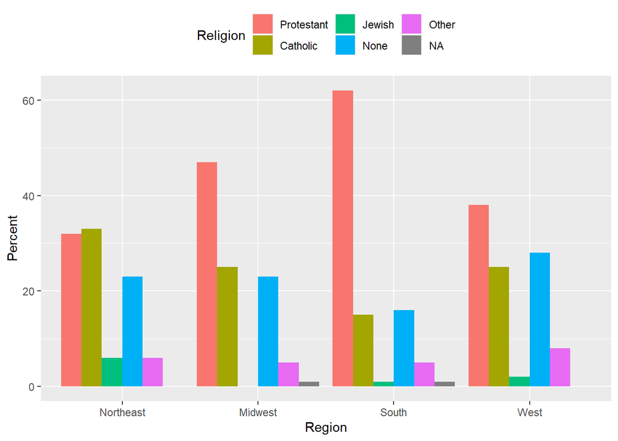

```r
p <- ggplot(rel_by_region,
            aes(x = bigregion, y = pct, fill = religion) )

p + geom_col( position = 'dodge') +
    labs(x = 'Region', y = 'Percent', fill = 'Religion') +
    theme(legend.position = 'top')
```

Utlizaremos **dodge2** em vez de **dodge** pois os dados já estão com as proporções computadas.

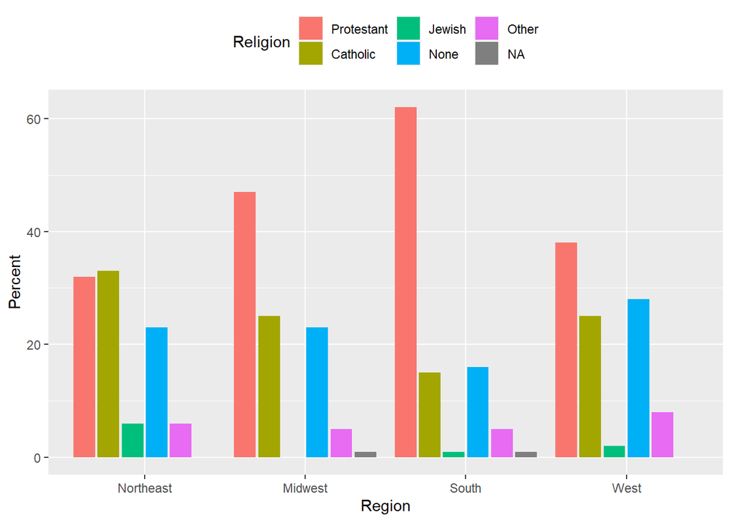

```r
p <- ggplot(rel_by_region,
            aes(x = bigregion, y = pct, fill = religion) )

p + geom_col( position = 'dodge2') +
    labs(x = 'Region', y = 'Percent', fill = 'Religion') +
    theme(legend.position = 'top')
```

Ainda sim existem várias barras uma ao lado da outra,uma alternativa é deitar o gráfico de barras através do **coord_flip()**.

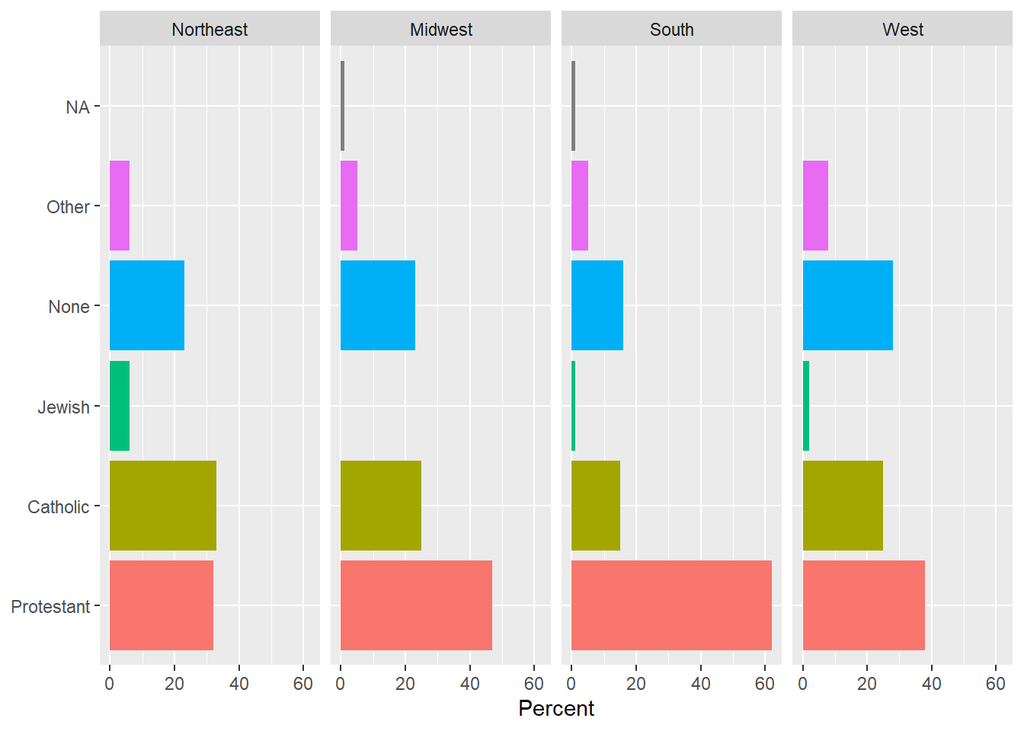

```r
p <- ggplot(rel_by_region,
            aes(x = religion, y = pct, fill = religion) )

p + geom_col( position = 'dodge2') +
    labs(x = NULL, y = 'Percent', fill = 'Religion') +
    guides(fill = FALSE) +
    coord_flip() +
    facet_grid(~ bigregion)
```

## Variáveis Contínuas agrupadas por Categoria ou Grupo

Utilizaremos o dataset *organdata* descrito neste [site](https://kjhealy.github.io/socviz/reference/organdata.html)

Podemos alternativamente ao **head()**,utilizar a função **sample_n()** para coletar 10 linhas aleatoriamente dos dados. Observe que também selecionamos as primeiras 6 colunas.

```r
organdata %>%
    select(1:6) %>%
    sample_n(size = 10)
```

```
## # A tibble: 10 x 6
##    country     year       donors   pop pop_dens   gdp
##    <chr>       <date>      <dbl> <int>    <dbl> <int>
##  1 Netherlands NA           NA      NA   NA        NA
##  2 Switzerland 1999-01-01   14.4  7144   17.3   28562
##  3 Austria     NA           NA    7678    9.16  18914
##  4 Australia   NA           NA   17065    0.220 16774
##  5 Germany     NA           NA      NA   NA        NA
##  6 Belgium     1994-01-01   22.8 10116   30.6   20732
##  7 Switzerland 1997-01-01   14.3  7089   17.2   27675
##  8 Austria     1992-01-01   23.1  7841    9.35  20601
##  9 Netherlands 2002-01-01   12.6 16149   38.9   28983
## 10 Netherlands 1996-01-01   15.1 15531   37.4   22541
```

Vamos plotar a taxa de doação de órgãos por milhão de população, donors, pelo tempo para começar a analisar os dados.

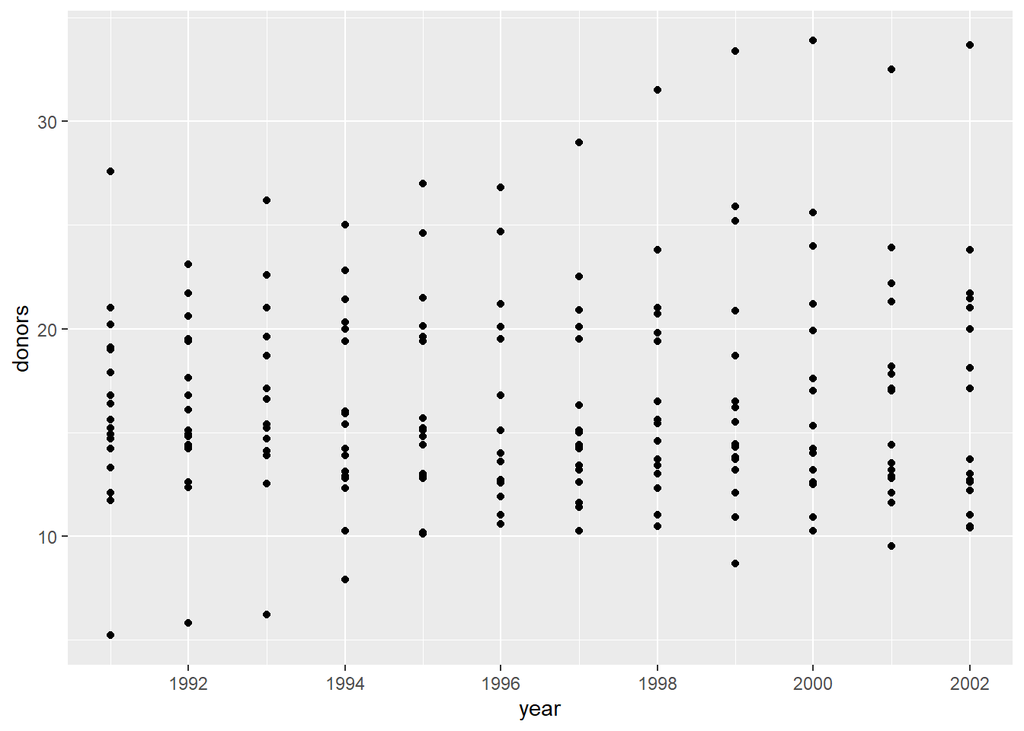

```r
p <- ggplot(data = organdata,
            mapping = aes(x = year, y = donors))

p + geom_point()
```

Não muito informativo por enquanto. Podemos plotar a série histórica da taxa de doação de cada país utilizando **geom_line()**:

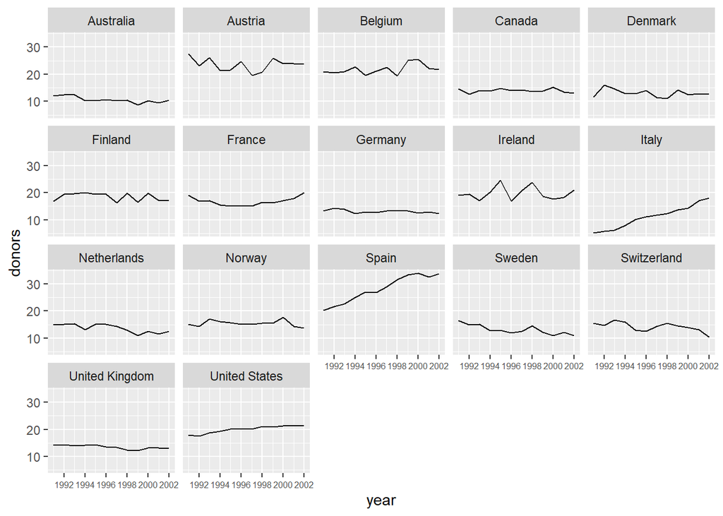

```r
p <- ggplot(data = organdata,
            mapping = aes(x = year, y = donors))

p + geom_line(aes(group = country)) +
  facet_wrap(~country) +
  theme(axis.text.x = element_text(size=6))
```

Focando agora não no tempo mas na variação da taxa de doação, plotaremos o boxplot de taxa de doação por país:

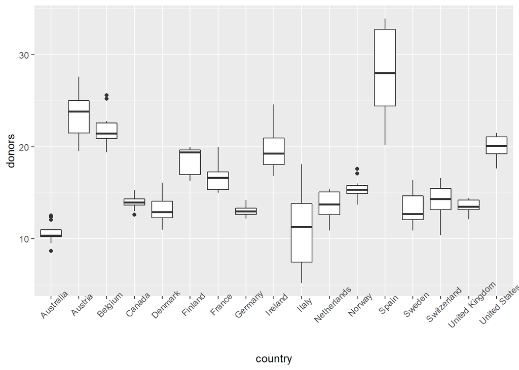

```r
p <- ggplot(data = organdata,
            mapping = aes(x = country, y = donors))

p + geom_boxplot() +
  theme(axis.text.x = element_text(angle = 45))
```

Observe que os países se sobrepoem, uma alternativa é deitar o gráfico usando **coord_flip()**:

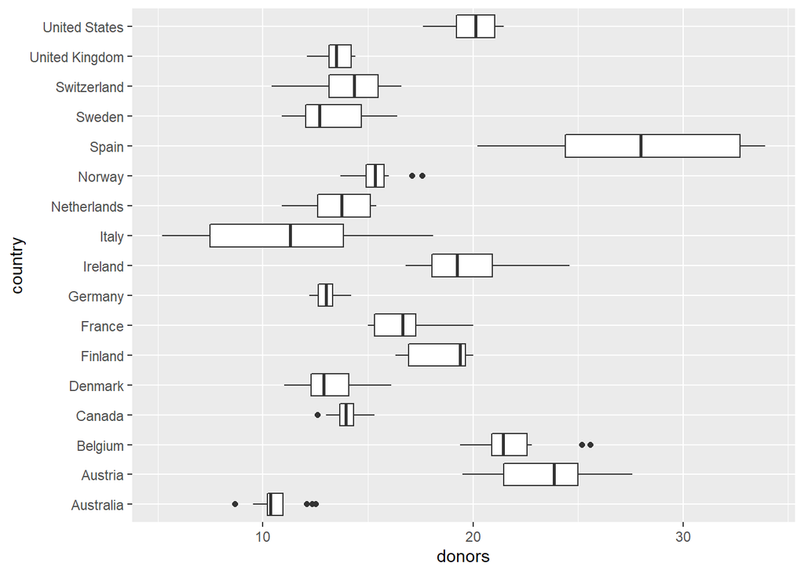

```r
p <- ggplot(data = organdata,
            mapping = aes(x = country, y = donors))

p + geom_boxplot() +
    coord_flip()
```

Mesmo mais legível, ele parece a priori pouco informativo, porque os países estão por ordem alfabética. Podemos reordená-los pela taxa de doações médias através da função **reorder()**

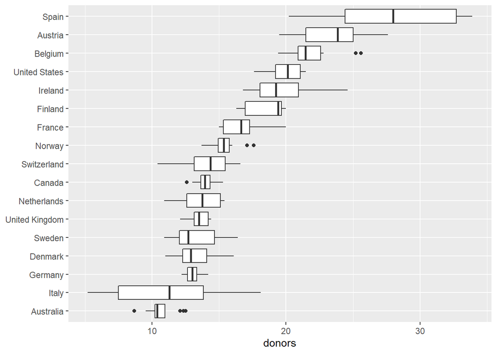

```r
p <- ggplot(data = organdata,
            mapping = aes(x = reorder(country,
                                      donors,
                                      na.rm = TRUE),
                          y = donors) )

p + geom_boxplot() +
    labs(x = NULL) +
    coord_flip()
```

Podemos alternativamente fazer o **Violin plot** através da função **geom_violin()**

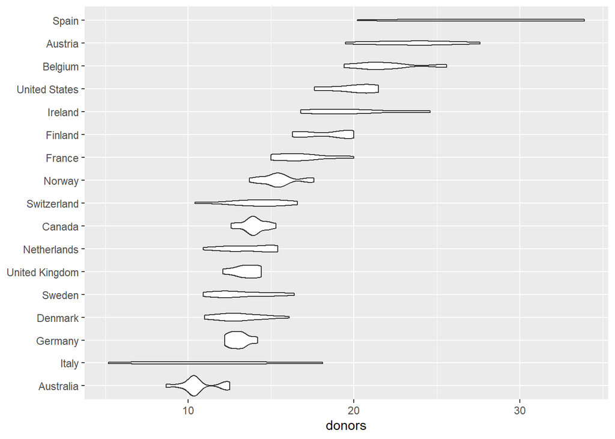

```r
p <- ggplot(data = organdata,
            mapping = aes(x = reorder(country,
                                      donors,
                                      na.rm = TRUE),
                          y = donors) )

p + geom_violin() +
    labs(x = NULL) +
    coord_flip()
```

Podemos também colorir os boxplots de acordo com a variável categórica **world**:

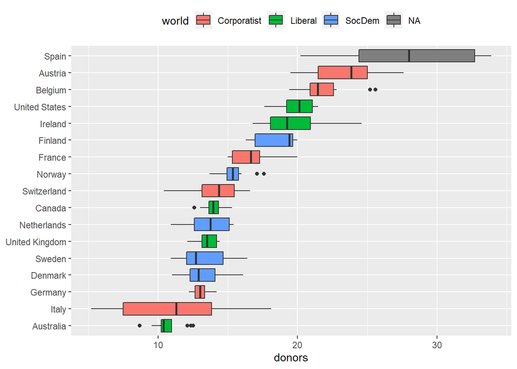

```r
p <- ggplot(data = organdata,
            mapping = aes(x = reorder(country, donors, na.rm = TRUE),
                          y = donors,
                          fill = world) )

p + geom_boxplot() +
    labs(x = NULL) +
    coord_flip() +
    theme(legend.position = 'top')
```

Colocando variáveis categóricas na vertical para comparar as distribuições é um bom recurso para resumir muitos pontos.Entretanto quando a quantidade de pontos por categoria é relativamente pequena, podemos simplismente plotar as observações.

Vamos utilizar a função **geom_point()** em vez de **geom_boxplot()** fazendo os devidos ajustes de parâmetros:

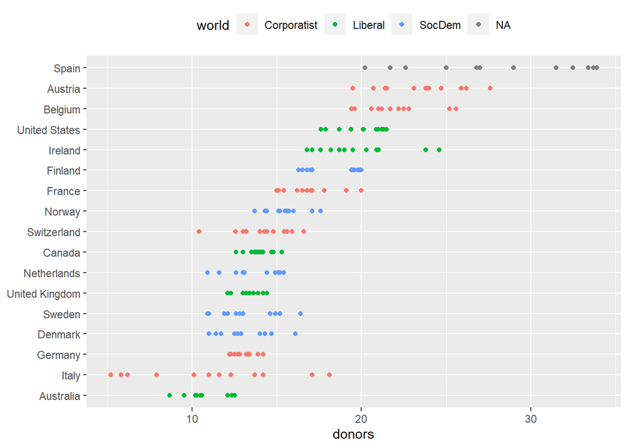

```r
p <- ggplot(data = organdata,
            mapping = aes(x = reorder(country, donors, na.rm = TRUE),
                          y = donors,
                          color = world) )

p + geom_point() +
    labs(x = NULL) +
    coord_flip() +
    theme(legend.position = 'top')
```

Perceba que desta forma, existe sobreposição de observações, nestes casos podemos perturbar os dados para evitar esta sobreposição através da função **geom_jitter()**:

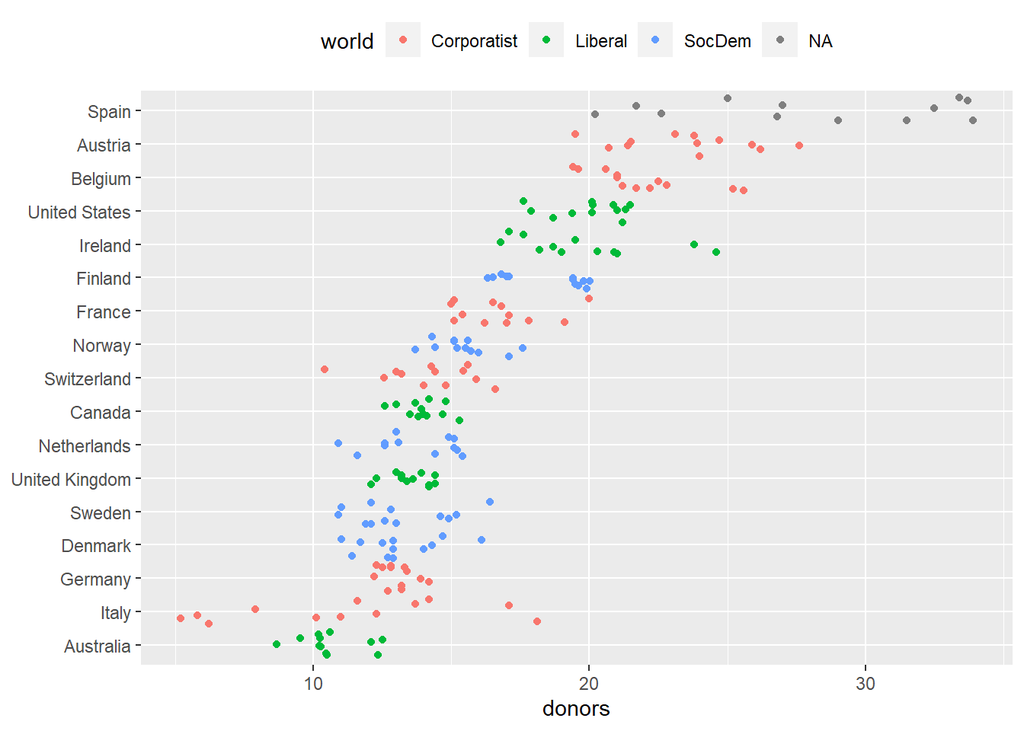

```r
p <- ggplot(data = organdata,
            mapping = aes(x = reorder(country, donors, na.rm = TRUE),
                          y = donors,
                          color = world) )

p + geom_jitter() +
    labs(x = NULL) +
    coord_flip() +
    theme(legend.position = 'top')
```

Podemos regular o grau de pertubação de dados com o parâmetros **width** e **height**:

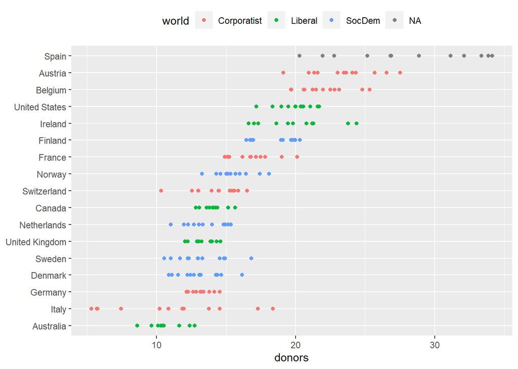

```r
p <- ggplot(data = organdata,
            mapping = aes(x = reorder(country, donors, na.rm = TRUE),
                          y = donors,
                          color = world) )

p + geom_jitter(position = position_jitter(width = 0,
                                           height = 0.5) ) +
    labs(x = NULL) +
    coord_flip() +
    theme(legend.position = 'top')
```

Dado o formato do gráfico, usaremos apenas o **width**, pois o **heigh** altera o eixo y (não esqueça que deitamos o gráfico), ou seja, altera a distribuição das observações.

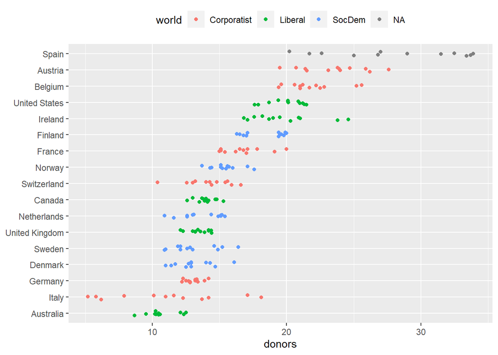

```r
p <- ggplot(data = organdata,
            mapping = aes(x = reorder(country, donors, na.rm = TRUE),
                          y = donors,
                          color = world) )

p + geom_jitter(position = position_jitter(width = 0.15) ) +
    labs(x = NULL) +
    coord_flip() +
    theme(legend.position = 'top')
```

Quando queremos resumir uma variável categórica com apenas um valor por catergoria, como a taxa média de doações por país, podemos usar o **Cleverland plot**.

```r
by_country <- organdata %>%
  group_by(consent_law, country) %>%
  summarize(donors_mean = mean(donors, na.rm = TRUE),
            donors_sd = sd(donors, na.rm = TRUE),
            gdp_mean = mean(gdp, na.rm = TRUE),
            health_mean = mean(health, na.rm = TRUE),
            roads_mean = mean(roads, na.rm = TRUE),
            cerebvas_mean = mean(cerebvas, na.rm = TRUE))
by_country
```

```
## # A tibble: 17 x 8
## # Groups:   consent_law [2]
##    consent_law country     donors_mean donors_sd gdp_mean health_mean roads_mean
##    <chr>       <chr>             <dbl>     <dbl>    <dbl>       <dbl>      <dbl>
##  1 Informed    Australia          10.6     1.14    22179.       1958.      105.
##  2 Informed    Canada             14.0     0.751   23711.       2272.      109.
##  3 Informed    Denmark            13.1     1.47    23722.       2054.      102.
##  4 Informed    Germany            13.0     0.611   22163.       2349.      113.
##  5 Informed    Ireland            19.8     2.48    20824.       1480.      118.
##  6 Informed    Netherlands        13.7     1.55    23013.       1993.       76.1
##  7 Informed    United Kin~        13.5     0.775   21359.       1561.       67.9
##  8 Informed    United Sta~        20.0     1.33    29212.       3988.      155.
##  9 Presumed    Austria            23.5     2.42    23876.       1875.      150.
## 10 Presumed    Belgium            21.9     1.94    22500.       1958.      155.
## 11 Presumed    Finland            18.4     1.53    21019.       1615.       93.6
## 12 Presumed    France             16.8     1.60    22603.       2160.      156.
## 13 Presumed    Italy              11.1     4.28    21554.       1757       122.
## 14 Presumed    Norway             15.4     1.11    26448.       2217.       70.0
## 15 Presumed    Spain              28.1     4.96    16933        1289.      161.
## 16 Presumed    Sweden             13.1     1.75    22415.       1951.       72.3
## 17 Presumed    Switzerland        14.2     1.71    27233        2776.       96.4
## # ... with 1 more variable: cerebvas_mean <dbl>
```

Ou alternativamente podemos fazer esta tarefa iterando através de recursos de programação funcional do R:

```r
by_country <- organdata %>%
  group_by(consent_law, country) %>%
    summarize_if(is.numeric, funs(mean, sd), na.rm = TRUE) %>%
    ungroup()
by_country
```

```
## # A tibble: 17 x 28
##    consent_law country  donors_mean pop_mean pop_dens_mean gdp_mean gdp_lag_mean
##    <chr>       <chr>          <dbl>    <dbl>         <dbl>    <dbl>        <dbl>
##  1 Informed    Austral~        10.6   18318.         0.237   22179.       21779.
##  2 Informed    Canada          14.0   29608.         0.297   23711.       23353.
##  3 Informed    Denmark         13.1    5257.        12.2     23722.       23275
##  4 Informed    Germany         13.0   80255.        22.5     22163.       21938.
##  5 Informed    Ireland         19.8    3674.         5.23    20824.       20154.
##  6 Informed    Netherl~        13.7   15548.        37.4     23013.       22554.
##  7 Informed    United ~        13.5   58187.        24.0     21359.       20962.
##  8 Informed    United ~        20.0  269330.         2.80    29212.       28699.
##  9 Presumed    Austria         23.5    7927.         9.45    23876.       23415.
## 10 Presumed    Belgium         21.9   10153.        30.7     22500.       22096.
## 11 Presumed    Finland         18.4    5112.         1.51    21019.       20763
## 12 Presumed    France          16.8   58056.        10.5     22603.       22211.
## 13 Presumed    Italy           11.1   57360.        19.0     21554.       21195.
## 14 Presumed    Norway          15.4    4386.         1.35    26448.       25769.
## 15 Presumed    Spain           28.1   39666.         7.84    16933        16584.
## 16 Presumed    Sweden          13.1    8789.         1.95    22415.       22094
## 17 Presumed    Switzer~        14.2    7037.        17.0     27233        26931.
## # ... with 21 more variables: health_mean <dbl>, health_lag_mean <dbl>,
## #   pubhealth_mean <dbl>, roads_mean <dbl>, cerebvas_mean <dbl>,
## #   assault_mean <dbl>, external_mean <dbl>, txp_pop_mean <dbl>,
## #   donors_sd <dbl>, pop_sd <dbl>, pop_dens_sd <dbl>, gdp_sd <dbl>,
## #   gdp_lag_sd <dbl>, health_sd <dbl>, health_lag_sd <dbl>, pubhealth_sd <dbl>,
## #   roads_sd <dbl>, cerebvas_sd <dbl>, assault_sd <dbl>, external_sd <dbl>,
## #   txp_pop_sd <dbl>
```

Com os dado resumidos por país, podemos fazer um **Cleveland dotplot** com os pontos coloridos conforme a variável categórica **consent_law**.

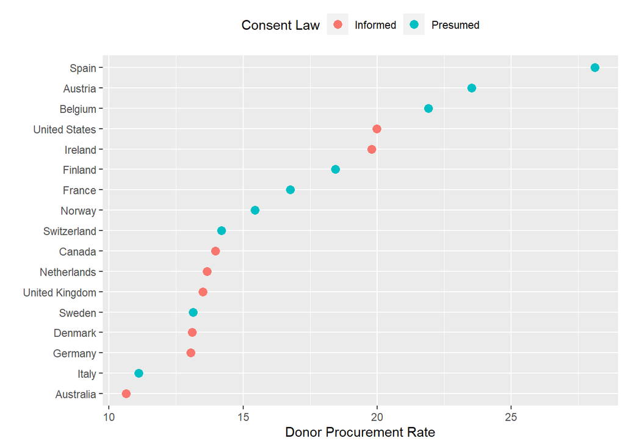

```r
p <- ggplot(data = by_country,
            mapping = aes(x = donors_mean,
                          y = reorder(country, donors_mean),
                          color = consent_law))
p + geom_point(size=3) +
    labs(x = "Donor Procurement Rate",
         y = "", color = "Consent Law") +
    theme(legend.position="top")
```

Alternativamente podemos plotar separadamente pela categoria **consent_law** em vez de colorir. Colocaremos os gráficos empilhados, **ncol = 1**, para melhor compará-los dado que são da mesma escala.

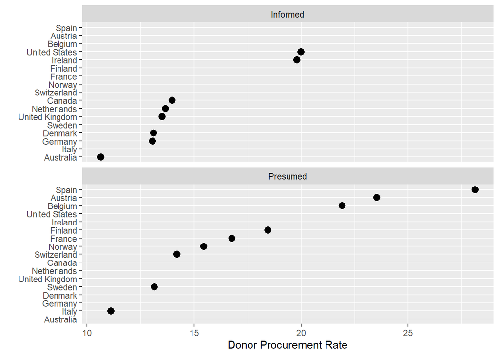

```r
p <- ggplot(data = by_country,
            mapping = aes(x = donors_mean,
                          y = reorder(country, donors_mean)))

p + geom_point(size=3) +
    facet_wrap(~ consent_law, ncol = 1) +
    labs(x= "Donor Procurement Rate",
         y= "")
```

Note que pelo eixo y ser categórico, ele vai plotar o nome todos os países nos 2 plots, então para evitar isso colocaremos **scales = “free_y”**.

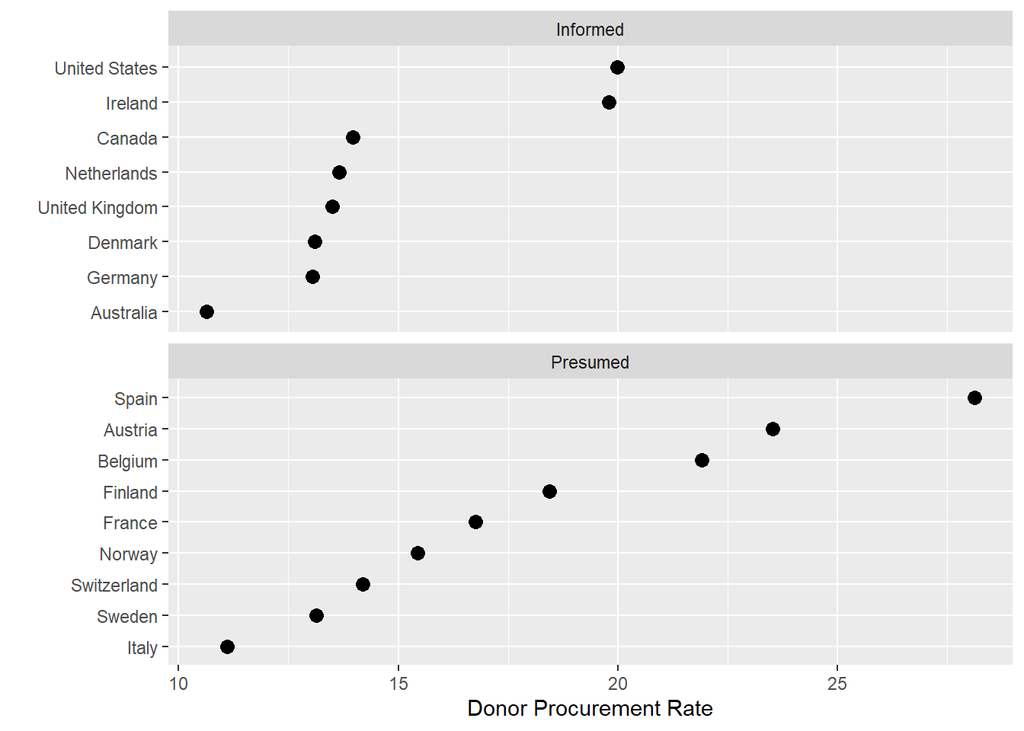

```r
p <- ggplot(data = by_country,
            mapping = aes(x = donors_mean,
                          y = reorder(country, donors_mean)))

p + geom_point(size=3) +
    facet_wrap(~ consent_law, scales = "free_y", ncol = 1) +
    labs(x= "Donor Procurement Rate",
         y= "")
```

**Cleverland plots** é um ótimo recurso de resumir resultados de dados que possuem erros de range. Para extender este tipo de plot e incluir medidas de variância ou erro utilizamos o **geom_pointrange**.

Este precisa do range em que se encontram os dados, **ymin** e **ymax**:

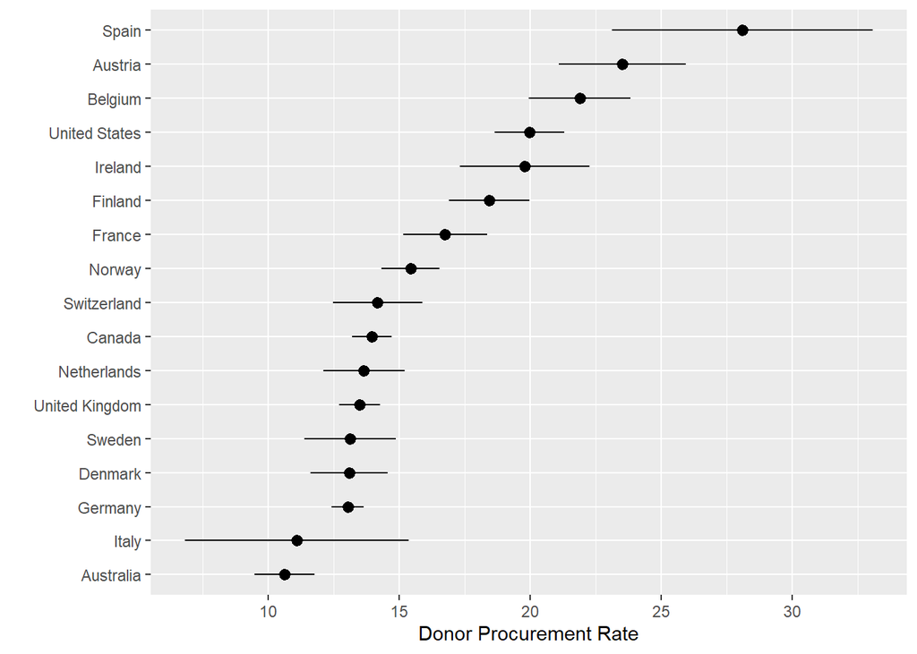

```r
p <- ggplot(data = by_country,
            mapping = aes(x = reorder(country,donors_mean),
                          y = donors_mean))

p + geom_pointrange(mapping = aes(ymin = donors_mean - donors_sd,
                                  ymax = donors_mean + donors_sd)) +
  labs(x= "", y= "Donor Procurement Rate") +
  coord_flip()
```

## Adicionando texto

Pode ser útil as vezes plotar os labels dos pontos diretamente, podemos fazer isso através da função **geom_text()**

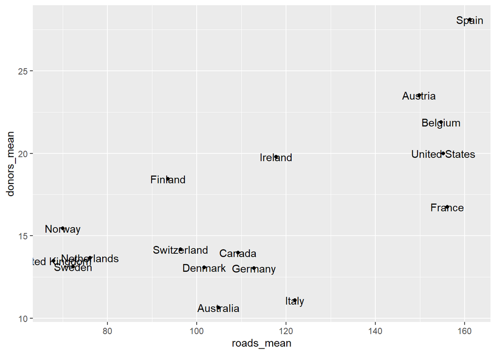

```r
p <- ggplot(data = by_country,
            mapping = aes(x = roads_mean,
                          y = donors_mean))

p + geom_point() +
  geom_text(mapping = aes(label = country))
```

Como estamos utilizando o mesmo **mapping** para os pontos e labels, eles ficam sobrepostos.

Para corrigir isso podemos retirar os pontos e manter os labels:

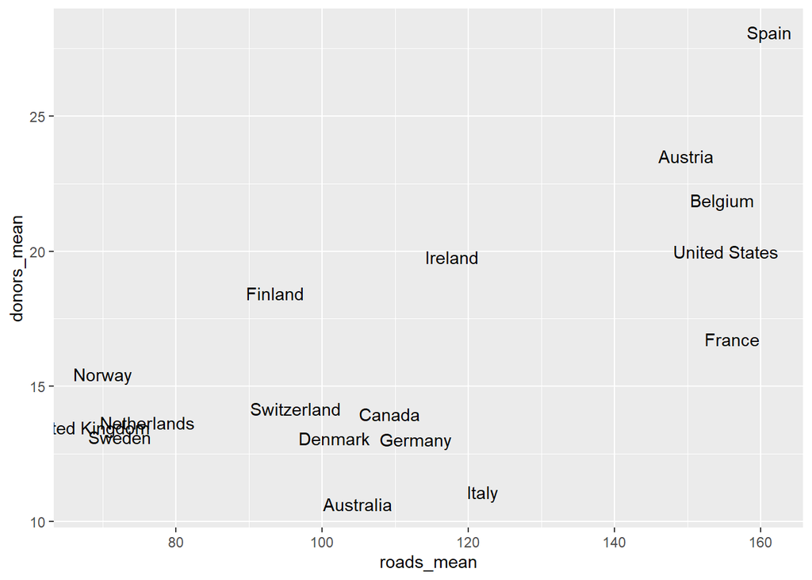

```r
p <- ggplot(data = by_country,
            mapping = aes(x = roads_mean,
                          y = donors_mean))

p + geom_text(mapping = aes(label = country))
```

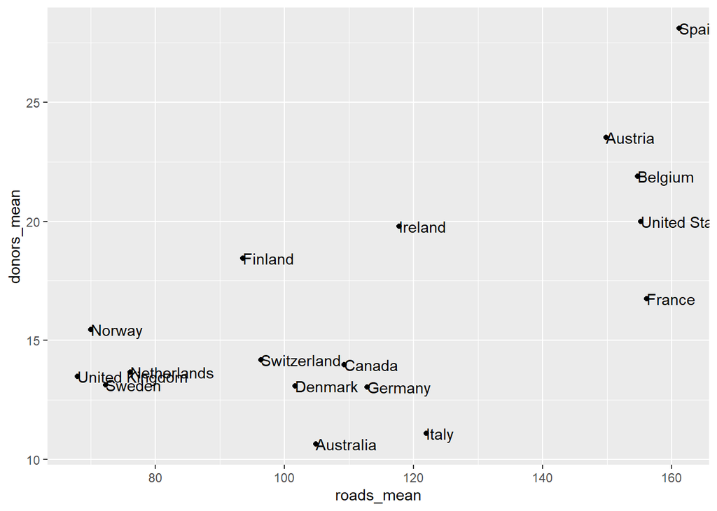

```r
p <- ggplot(data = by_country,
            mapping = aes(x = roads_mean,
                          y = donors_mean))

p + geom_point() +
  geom_text(mapping = aes(label = country),
            hjust = 0)
```

Perceba que por mais que modifiquemos o ajuste do label, não parece uma abordagem robusta. Em vez de usar **geom_text()** vamos usar as funções **geom_text_repel()** e **geom_label_repel()** da biblioteca **ggrepel**.

```r
library(ggrepel)
```

Vamos utilizar o dataset **elections_historic** descrito neste [site](https://kjhealy.github.io/socviz/reference/elections_historic.html)

```r
elections_historic %>% select(2:7)
```

```
## # A tibble: 49 x 6
##     year winner                 win_party ec_pct popular_pct popular_margin
##    <int> <chr>                  <chr>      <dbl>       <dbl>          <dbl>
##  1  1824 John Quincy Adams      D.-R.      0.322       0.309        -0.104
##  2  1828 Andrew Jackson         Dem.       0.682       0.559         0.122
##  3  1832 Andrew Jackson         Dem.       0.766       0.547         0.178
##  4  1836 Martin Van Buren       Dem.       0.578       0.508         0.142
##  5  1840 William Henry Harrison Whig       0.796       0.529         0.0605
##  6  1844 James Polk             Dem.       0.618       0.495         0.0145
##  7  1848 Zachary Taylor         Whig       0.562       0.473         0.0479
##  8  1852 Franklin Pierce        Dem.       0.858       0.508         0.0695
##  9  1856 James Buchanan         Dem.       0.588       0.453         0.122
## 10  1860 Abraham Lincoln        Rep.       0.594       0.396         0.101
## # ... with 39 more rows
```

A figura a seguir plota cada eleição presidencial Americana desde 1824, primeiro ano que foi computado o voto popular. Em que os eixos são a parcela de votos no vencedor e a parcela de votos do vencedor que são populares.

Estando interessados em certas presidências, vamos adicionar labels aos pontos. Porém para evitar sobreposição, como discutido anteriormente, vamos utilizar a função **geom_text_repel()**.

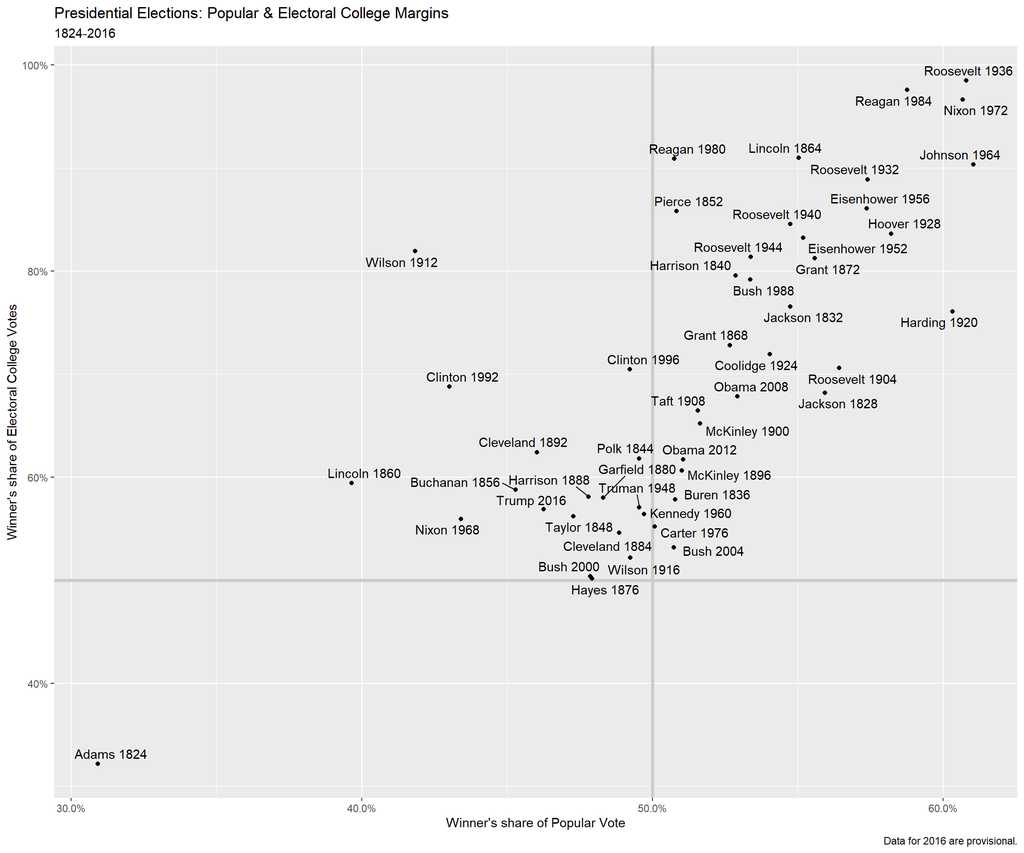

```r
p_title <- "Presidential Elections: Popular & Electoral College Margins"
p_subtitle <- "1824-2016"
p_caption <- "Data for 2016 are provisional."

x_label <- "Winner's share of Popular Vote"
y_label <- "Winner's share of Electoral College Votes"


p <- ggplot(elections_historic, aes(x = popular_pct,
                                    y = ec_pct,
                                    label = winner_label))

p + geom_hline(yintercept = 0.5,
               size = 1.4,
               color = "gray80") +
    geom_vline(xintercept = 0.5,
               size = 1.4,
               color = "gray80") +
    geom_point() +
    geom_text_repel() +
    scale_x_continuous(labels = scales::percent) +
    scale_y_continuous(labels = scales::percent) +
    labs(x = x_label,
         y = y_label,
         title = p_title,
         subtitle = p_subtitle,
         caption = p_caption)
```

Como os dados dos eixos estão em proporção, de 0 a 1, utilizamos a função **scale_x_continuous()** e **scale_y_continuous()** para transformá-los em porcentagens.

Adicionaremos retas que marcam 50% de votos no vencedor e 50% de votos do vencedor que são populares para melhor analisar o distanciamento de cada ponto destas retas.

## Texto condicional

Perceba que as vezes não é uma boa ideia nomear todos os pontos do plot, mas sim escolher alguns de interesse para adicionar seus labels. Podemos fazer isso ainda com as mesmas funções.

Basta que passemos um dataframe apenas com os pontos selecionados para a função **geom_text_repel()** através da ferramenta **subset()**. Como podemos ver a seguir:

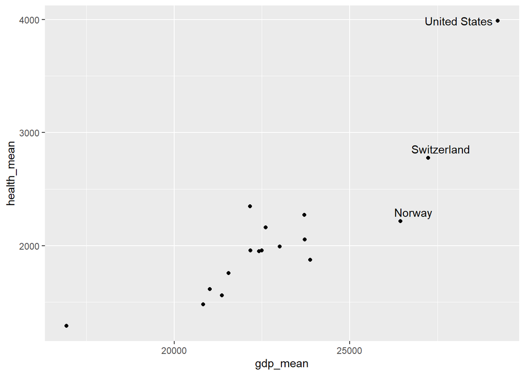

```r
p <- ggplot(data = by_country,
            mapping = aes(x = gdp_mean,
                          y = health_mean))

p + geom_point() +
    geom_text_repel(data = subset(by_country,
                                  gdp_mean > 25000),
                    mapping = aes(label = country))
```

Neste caso utilizamos um critério apenas, para mais critérios é de modo similar:

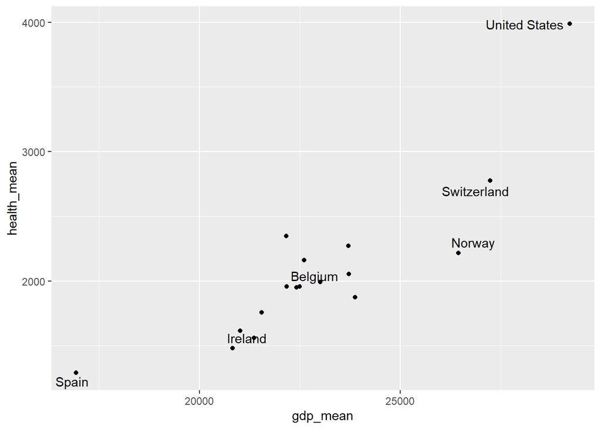

```r
p <- ggplot(data = by_country,
            mapping = aes(x = gdp_mean,
                          y = health_mean))

p + geom_point() +
    geom_text_repel(data = subset(by_country,
                                  gdp_mean > 25000 |
                                    health_mean < 1500 |
                                    country %in% "Belgium"),
                    mapping = aes(label = country))
```

Alternativamente, podemos selecionar pontos específicos criando uma variável auxiliar para essa tarefa, no caso abaixo criamos a coluna **ind**.

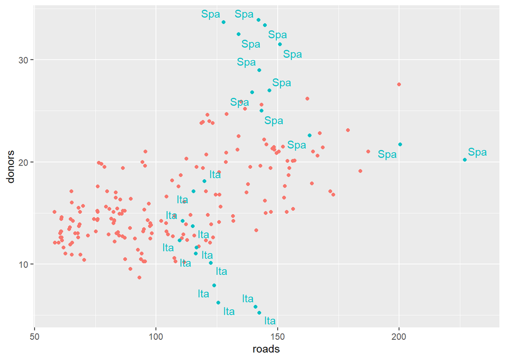

```r
organdata$ind <- organdata$ccode %in%
  c("Ita", "Spa") & organdata$year > 1998


p <- ggplot(data = organdata,
            mapping = aes(x = roads,
                          y = donors,
                          color = ind))

p + geom_point() +
    geom_text_repel(data = subset(organdata, ind),
                    mapping = aes(label = ccode)) +
    guides(label = FALSE,
           color = FALSE)
```

Utilizamos a coluna auxiliar tanto no filtro de labels quanto no parâmetro **color**. Além disso, para suprimir a legenda faz-se uso da função **guides()**.

## Escrevendo e desenhando no Gráfico

Por vezes se faz necessário fazer anotações diretamente no gráfico para fazer alguma observação. Utilizaremos a função **annotate()** e diremos para ela utilizar os argumentos da **geom_text()** através do parâmetro **geom**. Como pode-se ver no exemplo a seguir:

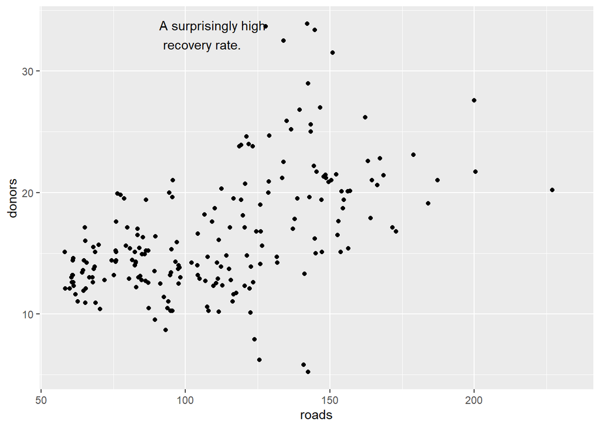

```r
p <- ggplot(data = organdata,
            mapping = aes(x = roads,
                          y = donors))

p + geom_point() +
  annotate(geom = "text",
           x = 91,
           y = 33,
           label = "A surprisingly high \n recovery rate.",
           hjust = 0)
```

Podemos fazer uso dos outros geoms, e desenhar retângulos, retas e setas. Vamos adicionar um retângulo para resaltar a quais pontos nossa observação se refere:

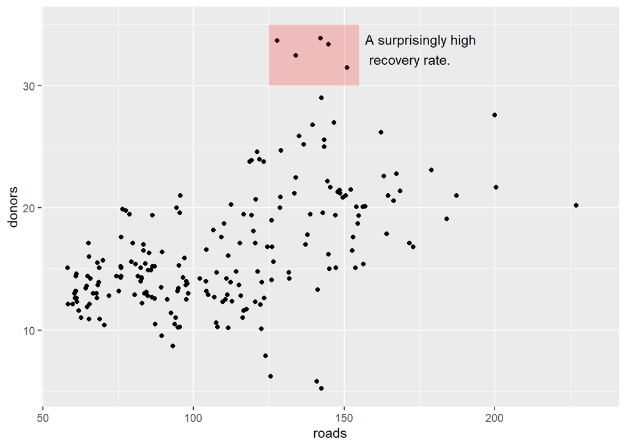

```r
p <- ggplot(data = organdata,
            mapping = aes(x = roads,
                          y = donors))

p + geom_point() +
    annotate(geom = "rect",
             xmin = 125, xmax = 155,
             ymin = 30, ymax = 35,
             fill = "red", alpha = 0.2) +
    annotate(geom = "text",
             x = 157, y = 33,
             label = "A surprisingly high \n recovery rate.",
             hjust = 0)
```

## Escalas, guias e Temas

A seguir temos um gráfico simples de dispersão:

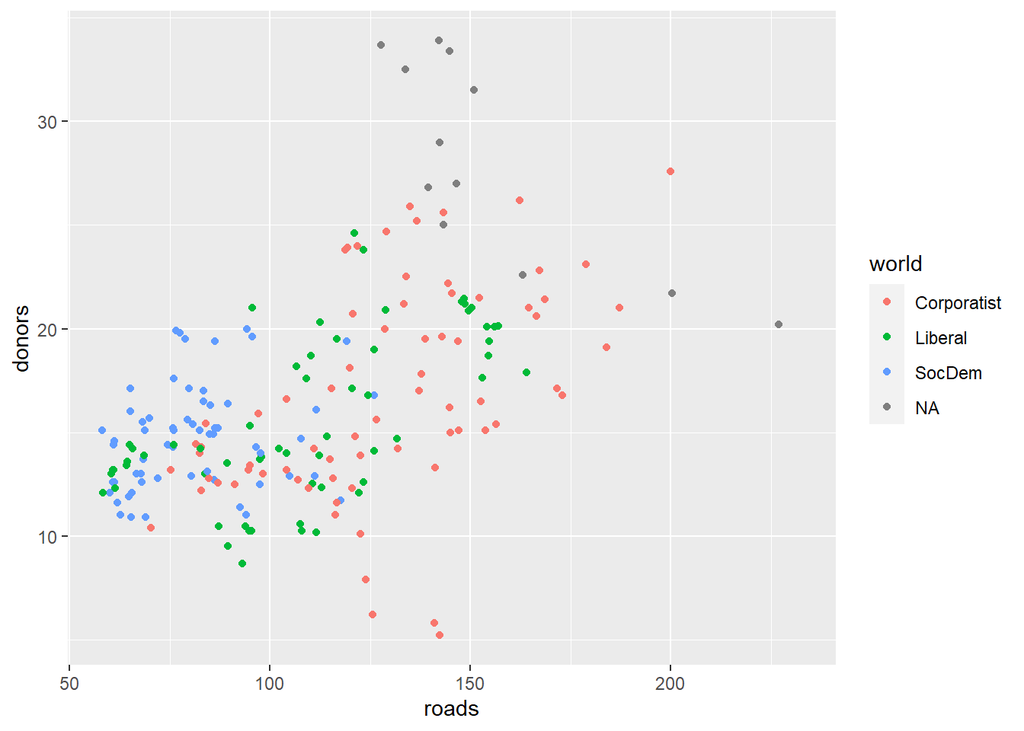

```r
p <- ggplot(data = organdata,
            mapping = aes(x = roads,
                          y = donors,
                          color = world))
p + geom_point()
```

Podemos mudar a escala do eixo através de uma função do tipo **scale_mapping_kind()**, além de mudar as escalas podemos definir as posições e os labels para as marcações do eixo. Como podemos ver a seguir:

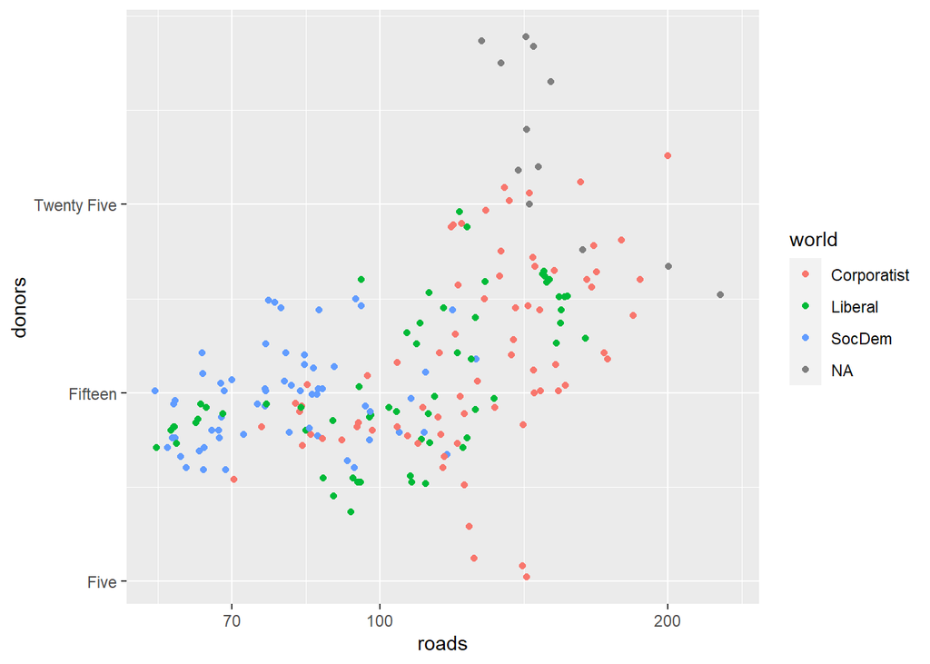

```r
p <- ggplot(data = organdata,
            mapping = aes(x = roads,
                          y = donors,
                          color = world))
p + geom_point() +
    scale_x_log10() +
    scale_y_continuous(breaks = c(5, 15, 25),
                       labels = c("Five",
                                  "Fifteen",
                                  "Twenty Five"))
```

Porém, se quisermos mudar os labels da legenda ou dos eixos em si, faremos isso utilizando a função **labs()** :

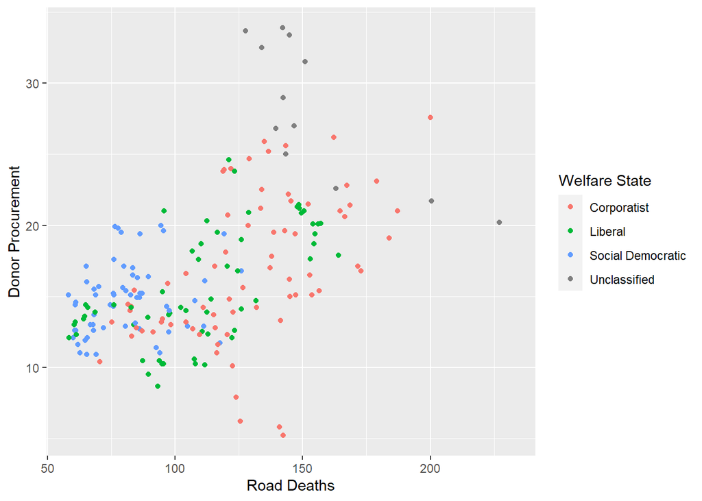

```r
p <- ggplot(data = organdata,
            mapping = aes(x = roads,
                          y = donors,
                          color = world))
p + geom_point() +
    scale_color_discrete(labels = c("Corporatist",
                                    "Liberal",
                                    "Social Democratic",
                                    "Unclassified")) +
    labs(x = "Road Deaths",
         y = "Donor Procurement",
         color = "Welfare State")
```

Por fim, para o caso de não querermos a legenda, podemos utilizar o **guides()**.

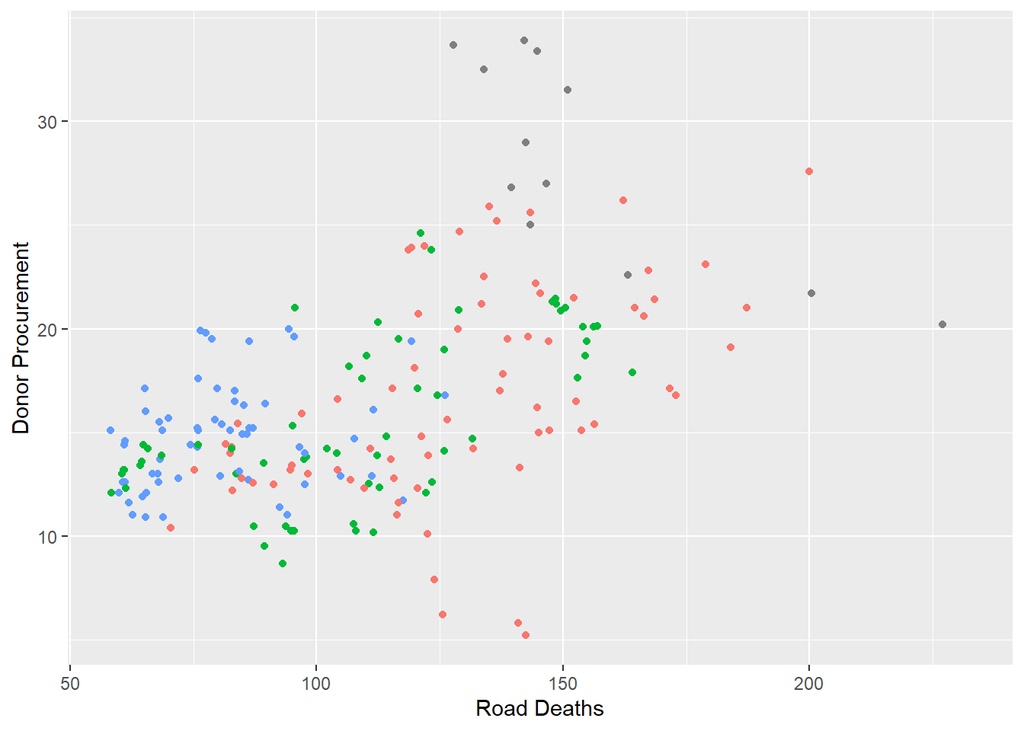

```r
p <- ggplot(data = organdata,
            mapping = aes(x = roads,
                          y = donors,
                          color = world))

p + geom_point() +
    labs(x = "Road Deaths",
         y = "Donor Procurement") +
    guides(color = FALSE)
```